# W3cubDocs

/Qt

# DistortionRipple QML Type

A ripple distortion effect. More...

| Import Statement: | import QtQuick3D.Effects |
| --- | --- |

- [List of all members, including inherited members](https://doc.qt.io/qt-6.2/qml-qtquick3d-effects-distortionripple-members.html)

## Properties

- **center** : vector2d
- **distortionHeight** : real
- **distortionPhase** : real
- **distortionWidth** : real
- **radius** : real

## Detailed Description

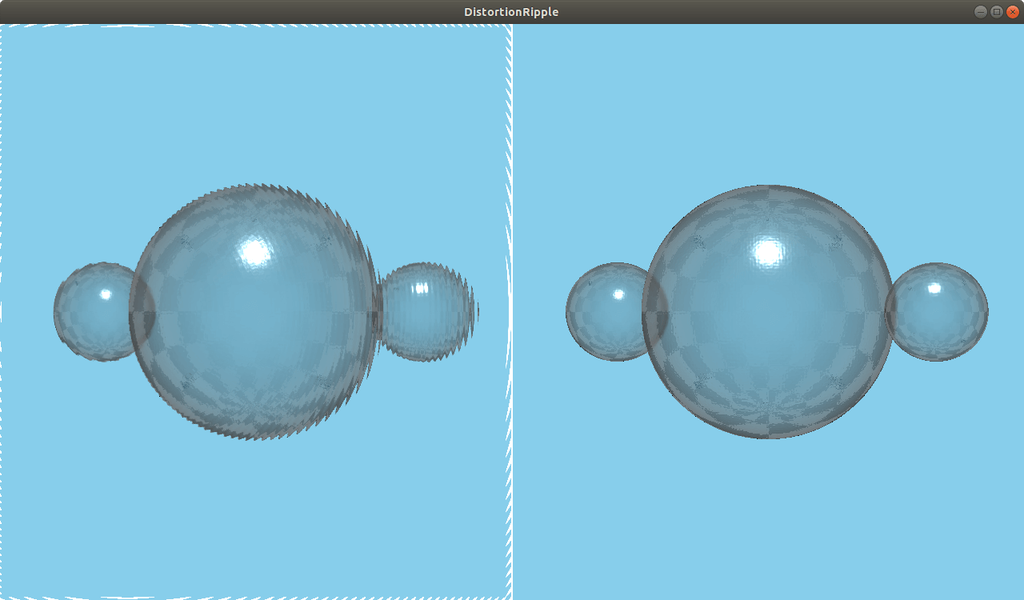

The DistortionRipple effect adds a wavelike distortion of circular ripples around a center point.

## Property Documentation

center : vector2d

The center point of the distortion. The default is `Qt.vector2d(0.5, 0.5)`, the center of the scene.

distortionHeight : real

The distortion amount. Sensible values are in the range `[0...100]`. The default value is `10`.

distortionPhase : real

The offset of each wave. Animate this property to see the waves move. Sensible values are in the range `[0...360]`. The default value is `0`.

distortionWidth : real

The width of a ripple. Sensible values are in the range `[2...100]`. The default value is `10`.

radius : real

How far the ripples extend from the center point. Sensible values are in the range `[0...100]`. The default value is `100`.

© The Qt Company Ltd  
Licensed under the GNU Free Documentation License, Version 1.3.  
https://doc.qt.io/qt-6.2/qml-qtquick3d-effects-distortionripple.html